Florian CHARRIAT

17 Avril 2018

# Résumé

# Annotation

- Braker :
> - Input :
> > - Assemblage au format Fasta
> > - Alignement de données RNAseq sur le genome au format Bam ou fichier gff des introns issus des données RNAseq
- Annotation :
> - Création d’un fichier gff des introns :
> > - Bam2hints : hints issus de l’alignement des données RNAseq
> > - Exonerate : hints issus de l’annotation des protéines de la souche 70-15

# Recherche de protéines sécrétées

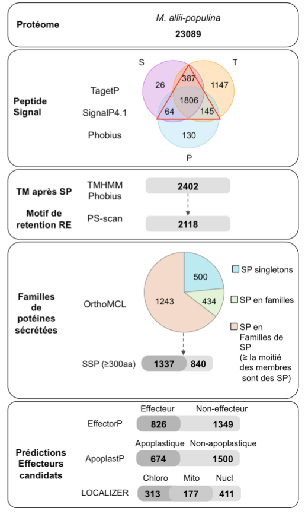

Figure 1: Pipeline de prédiction du secretome de Cecile Lorrain

# Comparaison outils

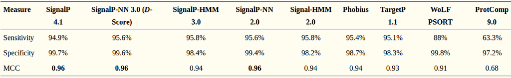

Tableau 1: Performance of secretion prediction tools applied to secreted fungal proteins sourced from SwissProt. Table issue de *Evaluation of secretion prediction highlights differing approaches needed for oomycete and fungal effectors* [1]

[1] Sperschneider J, Williams AH, Hane JK, Singh KB, Taylor JM. 2015. Evaluation of secretion prediction highlights differing approaches needed for oomycete and fungal effectors. Front Plant Sci 6:1168. doi:10.3389/fpls.2015.01168.

# Comparaison outils (suite)

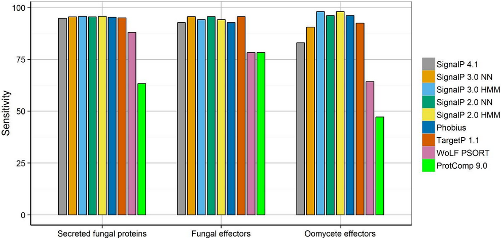

Tableau 2: Sensitivity of secretion prediction tools for secreted fungal proteins, fungal effectors, and oomycete effectors. Table issue de *Evaluation of secretion prediction highlights differing approaches needed for oomycete and fungal effectors* [1]

[1] Sperschneider J, Williams AH, Hane JK, Singh KB, Taylor JM. 2015. Evaluation of secretion prediction highlights differing approaches needed for oomycete and fungal effectors. Front Plant Sci 6:1168. doi:10.3389/fpls.2015.01168.